# Fitting and selecting models

Kaique S Alves

2021-06-14

## Base functions

`epifitter` provides functions for the fit of (non-flexible) two-parameter population dynamics models to disease progress curve (DPC) data: exponential, monomolecular, logistic and Gompertz.

The goal of fitting these models to DPCs is to estimate numerically meaningful parameters: `y0` that represents primary inoculum and `r`, representing the apparent infection rate. Hence, the importance of choosing the model that best describe the epidemics to better understand its proterties and compare epidemics.

Two approaches can be used to obtain the parameters:

- **Linear regression** models that are fitted to a specific transformation of the disease data according to each of the models.
- **Non-linear regression** models fitted to original data

Both approaches are available in *epifitter*. The simplest way to fit these models to single epidemic data is using the `fit_lin()` and `fit_nlin()` functions. For the latter, the alternative `fit_nlin2()` allows estimating a third parameter, the upper asymptote, when maximum disease intensity is not close to 100%. The `fit_multi()` function is the most flexible and allows to fit all models to multiple epidemic datasets.

First, we need to load the packages we’ll need for this tutorial.

```r
library(epifitter)
library(ggplot2)
library(dplyr)
library(magrittr)
library(cowplot)
```

## Basic usage

### Dataset

To use *epifitter* data at least two variables are needed, one representing the time of each assessment of disease intensity during the course of the epidemics and the other representing a disease intensity variable as proportion (e.g. incidence, severity, prevalence). For the case of designed experiments with replicates, a third variable is needed.

Let’s simulate a DPC dataset for one epidemics measured at replicated plots. The simulated data resemble a polyciclic epidemics of sigmoid shape. We can do that using the *epifitter* `sim_logistic()` function of epifitter (more about `?sim_logistic` here).

```r
dpcL <- sim_logistic(
  N = 100, # duration of the epidemics in days
  y0 = 0.01, # disease intensity at time zero
  dt = 10, # interval between assessments
  r = 0.1, # apparent infection rate
  alpha = 0.2, # level of noise
  n = 7 # number of replicates
)
```

Let’s give a look at the simulated dataset.

```r
head(dpcL)
```

```
##   replicates time          y   random_y
## 1          1    0 0.01000000 0.01055540
## 2          1   10 0.02672668 0.02336951
## 3          1   20 0.06946279 0.06498207
## 4          1   30 0.16868385 0.21762860
## 5          1   40 0.35549349 0.35448883
## 6          1   50 0.59989486 0.51236621
```

The `dpc_L` object generated using `sim_logistic()` is a dataframe with four columns. The `y` variable is a vector for the disease intensity as proportion (0 < y < 1). To facilitate visualization, let’s make a plot using the `ggplot` function of the *ggplot2* package.

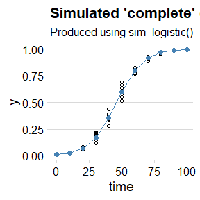

```r
ggplot(
  dpcL,
  aes(time, y,
    group = replicates
  )
) +
  geom_point(aes(time, random_y), shape = 1) + # plot the replicate values
  geom_point(color = "steelblue", size = 2) +
  geom_line(color = "steelblue") +
  labs(
    title = "Simulated 'complete' epidemics of sigmoid shape",
    subtitle = "Produced using sim_logistic()"
  )+
  theme_minimal_hgrid()
```

### Linear regression using `fit_lin()`

The `fit_lin()` requires at least the `time` and `y` arguments. In the example, we will call the `random_y` which represents the replicates. A quick way to call these variables attached to the dataframe is shown below.

```r
f_lin <- fit_lin(
  time = dpcL$time,
  y = dpcL$random_y
)
```

`fit_lin()` outputs a list object which contains several elements. Three elements of the list are shown by default: stats of model fit, Infection rate and Initial Inoculum

```r
f_lin
```

```
## Results of fitting population models
##
## Stats:
##                  CCC r_squared    RSE
## Logistic      0.9982    0.9964 0.1905
## Gompertz      0.9781    0.9571 0.4786
## Monomolecular 0.9349    0.8777 0.6504
## Exponential   0.9095    0.8340 0.6413
##
##  Infection rate:
##                 Estimate    Std.error      Lower      Upper
## Logistic      0.09924462 0.0006863749 0.09787729 0.09787729
## Gompertz      0.07053209 0.0017248354 0.06709605 0.06709605
## Monomolecular 0.05438023 0.0023440391 0.04971066 0.04971066
## Exponential   0.04486439 0.0023110106 0.04026062 0.04026062
##
##  Initial inoculum:
##                    Estimate Linearized     lin.SE         Lower         Upper
## Logistic       1.020060e-02  -4.575056 0.04060648  9.415405e-03  0.0110505437
## Gompertz       3.796373e-05  -2.320315 0.10204264  3.827309e-06  0.0002469124
## Monomolecular -1.738403e+00  -1.007375 0.13867523 -2.609720e+00 -1.0774053691
## Exponential    2.822122e-02  -3.567681 0.13672123  2.149266e-02  0.0370562487
```

#### Model fit stats

The `Stats` element of the list shows how each of the four models predicted the observations based on three measures:

- Lin’s concordance correlation coefficient `CCC` (Lin 2000), a measure of agreement that takes both bias and precision into account
- Coefficient of determination `r_squared` (R<sup>2</sup>), a measure of precision
- Residual standard deviation `RSE` for each model.

The four models are sorted from the high to the low `CCC`. As expected because the `sim_logistic` function was used to create the synthetic epidemic data, the the *Logistic* model was superior to the others.

#### Model coefficients

The estimates, and respective standard error and upper and lower 95% confidence interval, for the two coefficients of interest are shown in the `Infection rate` and `Initial inoculum` elements. For the latter, both the back-transformed (estimate) and the linearized estimate are shown.

#### Global stats

The element `f_lin$stats_all` provides a wide format dataframe with all the stats for each model.

```r
f_lin$stats_all
```

```
## # A tibble: 4 x 14
##   best_model model      r    r_se r_ci_lwr r_ci_upr    v0  v0_se r_squared   RSE
##        <int> <chr>  <dbl>   <dbl>    <dbl>    <dbl> <dbl>  <dbl>     <dbl> <dbl>
## 1          1 Logi~ 0.0992 6.86e-4   0.0979   0.101  -4.58 0.0406     0.996 0.190
## 2          2 Gomp~ 0.0705 1.72e-3   0.0671   0.0740 -2.32 0.102      0.957 0.479
## 3          3 Mono~ 0.0544 2.34e-3   0.0497   0.0590 -1.01 0.139      0.878 0.650
## 4          4 Expo~ 0.0449 2.31e-3   0.0403   0.0495 -3.57 0.137      0.834 0.641
## # ... with 4 more variables: CCC <dbl>, y0 <dbl>, y0_ci_lwr <dbl>,
## #   y0_ci_upr <dbl>
```

#### Model predictions

The predicted values are stored as a dataframe in the `data` element called using the same `$` operator as above. Both the observed and (`y`) and the back-transformed predictions (`predicted`) are shown for each model. The linearized value and the residual are also shown.

```r
head(f_lin$data)
```

```
##   time          y         model  linearized     predicted      residual
## 1    0 0.01055540   Exponential -4.55111775  2.822122e-02 -0.0176658249
## 2    0 0.01055540 Monomolecular  0.01061150 -1.738403e+00  1.7489584241
## 3    0 0.01055540      Logistic -4.54050625  1.020060e-02  0.0003548005
## 4    0 0.01055540      Gompertz -1.51537286  3.796373e-05  0.0105174358
## 5   10 0.02336951   Exponential -3.75632317  4.419971e-02 -0.0208302009
## 6   10 0.02336951 Monomolecular  0.02364691 -5.897434e-01  0.6131129216
```

#### Plot of predictions

The `plot_fit()` produces, by default, a panel of plots depicting the observed and predicted values by all fitted models. The arguments `pont_size` and `line_size` that control for the size of the dots for the observation and the size of the fitted line, respectively.

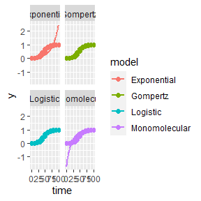

```r
plot_lin <- plot_fit(f_lin,
  point_size = 2,
  line_size = 1
)

# Default plots
plot_lin
```

#### Publication-ready plots

The plots are *ggplot2* objects which can be easily customized by adding new layers that override plot paramaters as shown below. The argument `models` allows to select the models(s) to be shown on the plot. The next plot was customized for the logistic model.

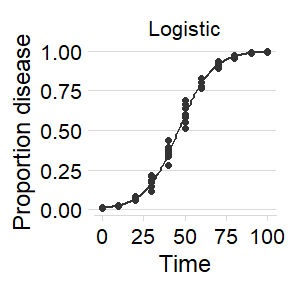

```r
# Customized plots

plot_fit(f_lin,
  point_size = 2,
  line_size = 1,
  models = "Logistic")+
  theme_minimal_hgrid(font_size =18) +
  scale_x_continuous(limits = c(0,100))+
  scale_color_grey()+
   theme(legend.position = "none")+
  labs(
    x = "Time",
    y = "Proportion disease "

  )
```

### Non-linear regression

#### Two-parameters

The `fit_nlin()` function uses the Levenberg-Marquardt algorithm for least-squares estimation of nonlinear parameters. In addition to time and disease intensity, starting values for `y0` and `r` should be given in the `starting_par` argument. The output format and interpretation is analogous to the `fit_lin()`.

> NOTE: If you encounter error messages saying “matrix at initial parameter estimates”, try to modify the starting values for the parameters to solve the problem.

```r
f_nlin <- fit_nlin(
  time = dpcL$time,
  y = dpcL$random_y,
  starting_par = list(y0 = 0.01, r = 0.03)
)

f_nlin
```

```
## Results of fitting population models
##
## Stats:
##                  CCC r_squared    RSE
## Logistic      0.9978    0.9956 0.0267
## Gompertz      0.9961    0.9932 0.0355
## Monomolecular 0.9173    0.8706 0.1512
## Exponential   0.8892    0.8278 0.1726
##
##  Infection rate:
##                 Estimate   Std.error      Lower      Upper
## Logistic      0.09720347 0.002091825 0.09303634 0.09303634
## Gompertz      0.06796614 0.001882452 0.06421611 0.06421611
## Monomolecular 0.02272553 0.001468476 0.01980018 0.01980018
## Exponential   0.01895276 0.001371656 0.01622028 0.01622028
##
##  Initial inoculum:
##                    Estimate    Std.error         Lower         Upper
## Logistic       1.143936e-02 1.119834e-03  9.208533e-03  1.367018e-02
## Gompertz       6.739623e-07 8.038978e-07 -9.274841e-07  2.275409e-06
## Monomolecular -1.901195e-01 4.523036e-02 -2.802230e-01 -1.000160e-01
## Exponential    1.819158e-01 2.072663e-02  1.406262e-01  2.232054e-01
```

We can check the results using `plot_fit`.

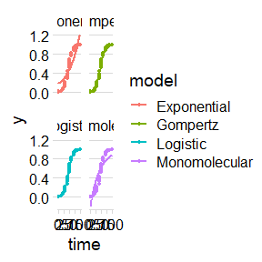

```r
plot_fit(f_nlin) +
  theme_minimal_hgrid()#changing plot theme
```

### Estimating `K` (maximum disease)

Before demonstrating the function, we can transform our simulated data by creating another variable with `y_random2` with maximum about 0.8 (80%). Simplest way is to multiply the `y_random` by 0.8.

```r
dpcL2 = dpcL %>%
  mutate(random_y = random_y * 0.8)
```

Then we run the `fit_nlin2()` for the new dataset.

```r
f_nlin2 <- fit_nlin2(
  time = dpcL2$time,
  y = dpcL2$random_y,
  starting_par = list(y0 = 0.01, r = 0.2, K =  0.6)
)
f_nlin2
```

```
## Results of fitting population models
##
## Stats:
##                  CCC r_squared    RSE
## Logistic      0.9978    0.9956 0.0215
## Gompertz      0.9723    0.9721 0.0735
## Monomolecular 0.9491    0.9095 0.0987
##
##  Infection rate:
##                 Estimate   Std.error      Lower      Upper
## Logistic      0.09746631 0.002578143 0.09232925 0.09232925
## Gompertz      0.10291939 0.012676727 0.07766046 0.07766046
## Monomolecular 0.01619790 0.003010469 0.01019941 0.01019941
##
##  Initial inoculum:
##                    Estimate    Std.error         Lower         Upper
## Logistic       9.064582e-03 1.020089e-03  7.032011e-03  1.109715e-02
## Gompertz       2.436658e-20 5.278079e-19 -1.027314e-18  1.076047e-18
## Monomolecular -1.435290e-01 3.143843e-02 -2.061715e-01 -8.088661e-02
##
##  Maximum disease intensity:
##                Estimate   Std.error     Lower     Upper
## Logistic      0.7990373 0.005392229 0.7882930 0.8097815
## Gompertz      0.6783335 0.015629770 0.6471905 0.7094765
## Monomolecular 1.0000000 0.105065932 0.7906516 1.2093484
```

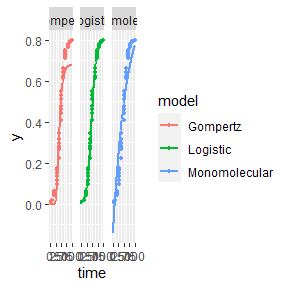

```r
plot_fit(f_nlin2)
```

### Fit models to multiple DPCs

Most commonly, there are more than one epidemics to analyse either from observational or experimental studies. When the goal is to fit a common model to all curves, the `fit_multi()` function is in hand. Each DPC needs an unique identified to further combined in a single data frame.

#### Data

Let’s use the `sim_` family of functions to create three epidemics and store the data in a single `data.frame`. The Gompertz model was used to simulate these data. Note that we allowed to the `y0` and `r` parameter to differ the DPCs. We should combine the three DPCs using the `bind_rows()` function and name the identifier (`.id`), automatically created as a character vector, for each epidemics as ‘DPC’.

```r
epi1 <- sim_gompertz(N = 60, y0 = 0.001, dt = 5, r = 0.1, alpha = 0.4, n = 4)
epi2 <- sim_gompertz(N = 60, y0 = 0.001, dt = 5, r = 0.12, alpha = 0.4, n = 4)
epi3 <- sim_gompertz(N = 60, y0 = 0.003, dt = 5, r = 0.14, alpha = 0.4, n = 4)

multi_epidemic <- bind_rows(epi1,
  epi2,
  epi3,
  .id = "DPC"
)
head(multi_epidemic)
```

```
##   DPC replicates time          y    random_y
## 1   1          1    0 0.00100000 0.001271050
## 2   1          1    5 0.01515505 0.006530227
## 3   1          1   10 0.07878459 0.082728939
## 4   1          1   15 0.21411521 0.146602867
## 5   1          1   20 0.39266393 0.581324792
## 6   1          1   25 0.56723412 0.680656350
```

We can visualize the three DPCs in a same plot

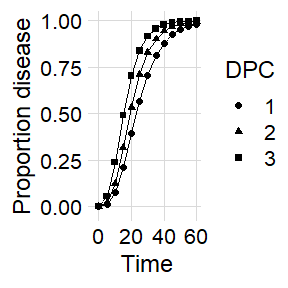

```r
p_multi <- ggplot(multi_epidemic,
       aes(time, y, shape = DPC, group = DPC))+
  geom_point(size =2)+
  geom_line()+
  theme_minimal_grid(font_size =18) +
   labs(
    x = "Time",
    y = "Proportion disease "

  )
p_multi
```

Or use `facet_wrap()` for ploting them separately.

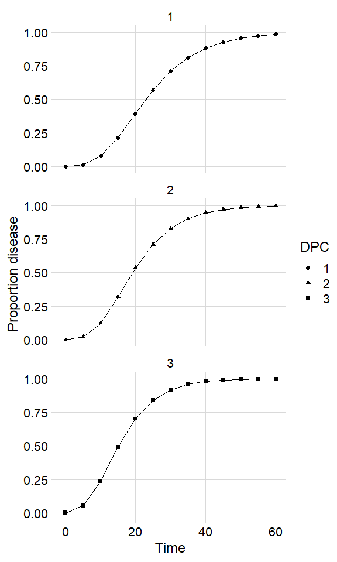

```r
p_multi +
  facet_wrap(~ DPC, ncol = 1)
```

#### Using `fit_multi()`

`fit_multi()` requires at least four arguments: time, disease intensity (as proportion), data and the curve identifier (`strata_cols`). The latter argument accepts one or more strata include as `c("strata1",strata2")`. In the example below, the stratum name is `DPC`, the name of the variable.

By default, the linear regression is fitted to data but adding another argument `nlin = T`, the non linear regressions is fitted instead.

```r
multi_fit <- fit_multi(
  time_col = "time",
  intensity_col = "random_y",
  data = multi_epidemic,
  strata_cols = "DPC"
)
```

All parameters of the list can be returned using the $ operator as below.

```r
head(multi_fit$Parameters)
```

```
##   DPC best_model         model          r        r_se   r_ci_lwr   r_ci_upr
## 1   1          1      Gompertz 0.09821178 0.002195383 0.09380222 0.10262133
## 2   1          2 Monomolecular 0.06948313 0.002684049 0.06409205 0.07487420
## 3   1          3      Logistic 0.15982894 0.007966187 0.14382838 0.17582949
## 4   1          4   Exponential 0.09034581 0.009484222 0.07129619 0.10939543
## 5   2          1      Gompertz 0.11852166 0.002360533 0.11378039 0.12326293
## 6   2          2 Monomolecular 0.09167920 0.002854558 0.08594565 0.09741274
##           v0      v0_se r_squared       RSE       CCC           y0
## 1 -1.9169085 0.07761853 0.9756249 0.2961734 0.9876621  0.001113882
## 2 -0.5664232 0.09489548 0.9305709 0.3620981 0.9640370 -0.761953549
## 3 -4.6898578 0.28164724 0.8895127 1.0746974 0.9415260  0.009104342
## 4 -4.1234347 0.33531788 0.6447423 1.2794915 0.7840040  0.016188816
## 5 -1.8815799 0.08345745 0.9805524 0.3184533 0.9901807  0.001410421
## 6 -0.6581823 0.10092387 0.9537674 0.3851009 0.9763367 -0.931278644
##       y0_ci_lwr    y0_ci_upr
## 1  0.0003536786  0.002972673
## 2 -1.1319271539 -0.456184984
## 3  0.0051913173  0.015919660
## 4  0.0082549650  0.031747894
## 5  0.0004257066  0.003884162
## 6 -1.3652739486 -0.576915522
```

Similarly, all data can be returned.

```r
head(multi_fit$Data)
```

```
##   DPC time           y         model   linearized    predicted      residual
## 1   1    0 0.001271050   Exponential -6.667911942  0.016188816 -0.0149177657
## 2   1    0 0.001271050 Monomolecular  0.001271858 -0.761953549  0.7632245990
## 3   1    0 0.001271050      Logistic -6.666640083  0.009104342 -0.0078332917
## 4   1    0 0.001271050      Gompertz -1.897306759  0.001113882  0.0001571676
## 5   1    5 0.006530227   Exponential -5.031313542  0.025433054 -0.0189028266
## 6   1    5 0.006530227 Monomolecular  0.006551642 -0.244840653  0.2513708799
```

If nonlinear regression is preferred, the `nlim` argument should be set to `TRUE`

```r
multi_fit2 <- fit_multi(
  time_col = "time",
  intensity_col = "random_y",
  data = multi_epidemic,
  strata_cols = "DPC",
  nlin = TRUE)
head(multi_fit2$Parameters)
```

```
##   DPC         model           y0       y0_se          r        r_se df
## 1   1      Gompertz  0.002280391 0.001681920 0.09626016 0.005251680 50
## 2   1      Logistic  0.039144718 0.008600833 0.13602253 0.009151714 50
## 3   1 Monomolecular -0.176213275 0.044607831 0.04294814 0.002682913 50
## 4   1   Exponential  0.233015208 0.029801544 0.02709389 0.002658825 50
## 5   2      Gompertz  0.001446817 0.001145185 0.12045152 0.006359237 50
## 6   2      Logistic  0.034188983 0.007488674 0.17166441 0.011026012 50
##         CCC r_squared        RSE     y0_ci_lwr    y0_ci_upr   r_ci_lwr
## 1 0.9861538 0.9728696 0.06273872 -0.0010978443  0.005658626 0.08571185
## 2 0.9802648 0.9641285 0.07447002  0.0218694370  0.056419999 0.11764077
## 3 0.9485483 0.9137056 0.11554402 -0.2658107401 -0.086615810 0.03755935
## 4 0.8575975 0.7791407 0.18274395  0.1731570441  0.292873372 0.02175348
## 5 0.9898959 0.9801426 0.05459555 -0.0008533554  0.003746989 0.10767861
## 6 0.9861310 0.9745902 0.06363181  0.0191475399  0.049230427 0.14951801
##     r_ci_upr best_model
## 1 0.10680847          1
## 2 0.15440429          2
## 3 0.04833693          3
## 4 0.03243430          4
## 5 0.13322442          1
## 6 0.19381080          2
```

#### Want to estimate K?

If you want to estimate `K`, set `nlin = TRUE` and `estimate_K = TRUE`.

> NOTE: If you do not set both arguments `TRUE`, `K` will not be estimated, because `nlin` defaut is `FALSE`. Also remember that when estimating K, we don’t fit the *Exponential* model.

```r
multi_fit_K <- fit_multi(
  time_col = "time",
  intensity_col = "random_y",
  data = multi_epidemic,
  strata_cols = "DPC",
  nlin = T,
  estimate_K = T
)
head(multi_fit_K$Parameters)
```

```
##   DPC         model           y0       y0_se          r        r_se K
## 1   1      Gompertz  0.002280415 0.002107445 0.09626007 0.008097060 1
## 2   1      Logistic  0.039144032 0.009818978 0.13602314 0.011629011 1
## 3   1 Monomolecular -0.176212702 0.049324231 0.04294809 0.006965794 1
## 4   2      Gompertz  0.001446733 0.001328401 0.12045191 0.008414188 1
## 5   2      Logistic  0.034187990 0.008132438 0.17166556 0.012741923 1
## 6   2 Monomolecular -0.172163373 0.049285646 0.05279902 0.007127714 1
##         K_se df       CCC r_squared        RSE    y0_ci_lwr    y0_ci_upr
## 1 0.02357226 49 0.9861538 0.9728695 0.06337568 -0.001954653  0.006515484
## 2 0.02316135 49 0.9802649 0.9641283 0.07522608  0.019412057  0.058876008
## 3 0.06896096 49 0.9485483 0.9137058 0.11671708 -0.275333455 -0.077091949
## 4 0.01519960 49 0.9898959 0.9801426 0.05514984 -0.001222788  0.004116254
## 5 0.01540082 49 0.9861310 0.9745901 0.06427783  0.017845244  0.050530736
## 6 0.04913822 49 0.9532828 0.9225229 0.11357507 -0.271206587 -0.073120159
##     r_ci_lwr   r_ci_upr  K_ci_lwr K_ci_upr best_model
## 1 0.07998842 0.11253172 0.9526298 1.047370          1
## 2 0.11265377 0.15939252 0.9534555 1.046544          2
## 3 0.02894980 0.05694637 0.8614178 1.138582          3
## 4 0.10354297 0.13736086 0.9694553 1.030545          1
## 5 0.14605970 0.19727141 0.9690509 1.030949          2
## 6 0.03847535 0.06712270 0.9012531 1.098747          3
```

### Graphical outputs

Use [`ggplot2`](https://ggplot2.tidyverse.org/) to produce elegant data visualizations of models curves and the estimated parameters.

#### DPCs and fitted curves

The original data and the predicted values by each model are stored in `multi_fit$Data`. A nice plot can be produced as follows:

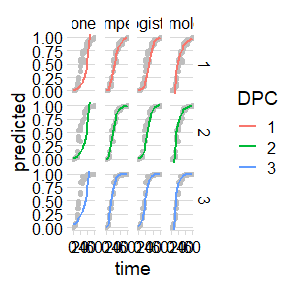

```r
multi_fit$Data %>%
  ggplot(aes(time, predicted, color = DPC)) +
  geom_point(aes(time, y), color = "gray") +
  geom_line(size = 1) +
  facet_grid(DPC ~ model, scales = "free_y") +
  theme_minimal_hgrid()+
  coord_cartesian(ylim = c(0, 1))
```

Using the *dplyr* function `filter` only the model of interest can be chosen for plotting.

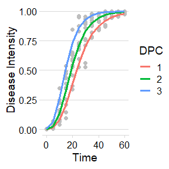

```r
multi_fit$Data %>%
  filter(model == "Gompertz") %>%
  ggplot(aes(time, predicted, color = DPC)) +
  geom_point(aes(time, y),
    color = "gray",
    size = 2
  ) +
  geom_line(size = 1.2) +
  theme_minimal_hgrid() +
  labs(
    x = "Time",
    y = "Disease Intensity"
  )
```

#### Apparent infection rate

The `multi_fit$Parameters` element is where all stats and parameters as stored. Let’s plot the estimates of the apparent infection rate.

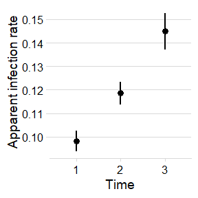

```r
multi_fit$Parameters %>%
  filter(model == "Gompertz") %>%
  ggplot(aes(DPC, r)) +
  geom_point(size = 3) +
  geom_errorbar(aes(ymin = r_ci_lwr, ymax = r_ci_upr),
    width = 0,
    size = 1
  ) +
  labs(
    x = "Time",
    y = "Apparent infection rate"
  ) +
  theme_minimal_hgrid()
```

## References

Lin L (2000). A note on the concordance correlation coefficient. Biometrics 56: 324 - 325.